# R Notebook

### Set up

```r
library(data.table)
library(tidyr)
library(igraph)
library(dplyr)
library(parallel)

path <- "/home/carolpb/DegreeProject/" # to use on Uppmax
respath <- "/proj/snic2019-8-367/private/carol/results/"

#respath <- "/Users/Carolina/Documents/GitHub/DegreeProject/results/"
#path <- "/Users/Carolina/Documents/GitHub/DegreeProject/" to use on my computer

source(paste0(path,"code/myfunctions.R"))

nSNPs <- 42052
nGenes <- 5720

snp.pval <- 0.05/(as.numeric(nGenes) * as.numeric(nSNPs))
snp.pval.nsign <- as.numeric(1e-5)

corr.pval <-  0.05/(nGenes*nGenes)

effects_table.cor <- fread(paste0(path, "results/2020-01-10/effectstable.gz"))
```

### Create table with cases where A->B is true and B->A is false

```r
find.effects <- effects_table.cor[cor.pval < corr.pval & cis.A ==T & cis.B==T & geneA!=geneB]
find.effects <- find.effects_fun(find.effects, snp.pval, snp.pval.nsign)
find.effects_TF.1 <- find.effects[find.effects$`A->B`==T & find.effects$`B->A`==F, .(geneA, geneB, eqtl.A, eqtl.B, `A->B`, `B->A`, eqtlA_geneB.pval)]
find.effects_TF.2 <- rbind(find.effects_TF.1, find.effects[find.effects$`A->B`==F & find.effects$`B->A`==T, .(geneA=geneB, geneB=geneA, eqtl.A=eqtl.B, eqtl.B=eqtl.A, `A->B`=`B->A`, `B->A`=`A->B`, eqtlA_geneB.pval=eqtlB_geneA.pval)])
find.effects_TF <- unique(find.effects_TF.2)
find.effects_TF
```

| geneA | geneB | eqtl.A | eqtl.B | A->B | B->A | eqtlA_geneB.pval |
| --- | --- | --- | --- | --- | --- | --- |
| YAL003W | YAL033W | chrI:133174_G/A | chrI:84112_T/C | TRUE | FALSE | 2.271552e-12 |
| YAL032C | YAL049C | chrI:84112_T/C | chrI:52951_G/T | TRUE | FALSE | 6.475010e-32 |
| YAL032C | YAL056W | chrI:84112_T/C | chrI:39162_C/G | TRUE | FALSE | 3.490420e-22 |
| YAL032C | YAL060W | chrI:84112_T/C | chrI:35818_A/G | TRUE | FALSE | 4.691849e-11 |
| YAL032C | YAL062W | chrI:84112_T/C | chrI:33293_A/T | TRUE | FALSE | 2.071276e-16 |
| YAL032C | YGL205W | chrI:84112_T/C | chrVII:100285_C/G | TRUE | FALSE | 4.923864e-20 |
| YAL032C | YGR035C | chrI:84112_T/C | chrVII:462915_C/T | TRUE | FALSE | 2.644160e-16 |
| YAL039C | YGR035C | chrI:70024_T/C | chrVII:462915_C/T | TRUE | FALSE | 5.284588e-41 |
| YAL039C | YMR246W | chrI:70024_T/C | chrXIII:759679_C/CT | TRUE | FALSE | 2.213893e-11 |
| YAL039C | YOR363C | chrI:70024_T/C | chrXV:1023392_T/G | TRUE | FALSE | 1.503556e-10 |

[output cut: 990 more lines]

## Histogram of p-vals

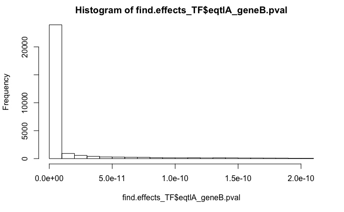

```r
hist(find.effects_TF$eqtlA_geneB.pval)
```

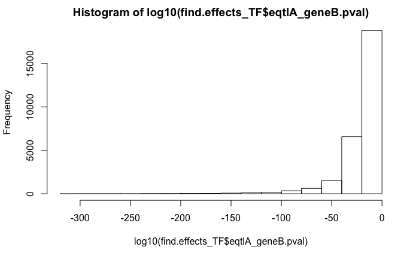

```r
hist(log10(find.effects_TF$eqtlA_geneB.pval))
```

## Gene pairs

Get table with how many times a gene pair appears - N==1 - these pairs only appear once N==2 - these pairs appear twice N==3 - these pairs appear three times

This shows that most gene pairs only appear once

```r
find.effects_TF.numpairs <- find.effects_TF[(`A->B`==T & `B->A`==F), .N, by=.(geneA, geneB)]
numpairs.table <- data.table(N = unique(find.effects_TF.numpairs$N), numpairs =NA)
for (i in 1:nrow(numpairs.table)){
  numpairs.table$numpairs[i] <- nrow(find.effects_TF.numpairs[N==numpairs.table$N[i]])
}
numpairs.table
```

| N | numpairs |
| --- | --- |
| 1 | 27359 |
| 2 | 488 |
| 3 | 8 |

### plot the number of times a gene pair appears

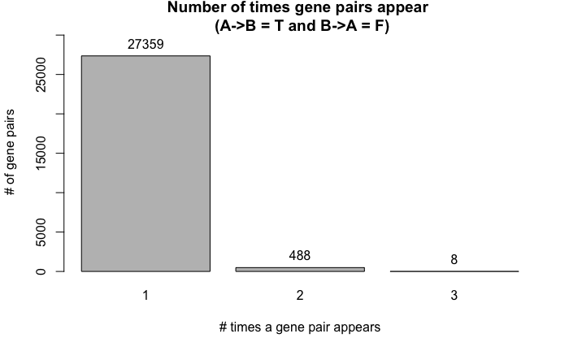

```r
bp <- barplot(numpairs.table$numpairs, numpairs.table$N, names.arg=unique(find.effects_TF.numpairs$N),
              width = 0.5, space=0.2, legend.text = F, ylim = c(0,max(numpairs.table$numpairs)+3000),
              main = "Number of times gene pairs appear \n (A->B = T and B->A = F)", xlab = "# times a gene pair appears",
              ylab = "# of gene pairs")
text(bp,numpairs.table$numpairs, labels=numpairs.table$numpairs, cex=1, pos=3)
```

## Gene-eqtl pairs

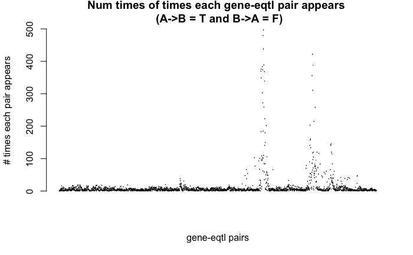

```r
find.effects_TF.geneeqtl.A <- find.effects_TF[(`A->B`==T & `B->A`==F), .N, by=.(geneA, eqtl.A)]
find.effects_TF.geneeqtl.B <- find.effects_TF[(`A->B`==T & `B->A`==F), .N, by=.(geneB, eqtl.B)]
find.effects_TF.geneeqtl.A.plot <- find.effects_TF.geneeqtl.A %>% unite(gene_eqtlA, geneA, eqtl.A, sep = "__")
#find.effects_TF.geneeqtl.B.plot <- find.effects_TF.geneeqtl.B %>% unite(gene_eqtlB, geneB, eqtl.B, sep = "__")
plot(as.factor(find.effects_TF.geneeqtl.A.plot$gene_eqtlA), find.effects_TF.geneeqtl.A.plot$N,
     xlab="gene-eqtl pairs", ylab="# times each pair appears", axes=FALSE,
     main="Num times of times each gene-eqtl pair appears \n (A->B = T and B->A = F)")
Axis(side=2, labels=T)
```

### Find number of times a gene-eqtl pair appears (for geneA-eqtlA –> the “origin”/ the gene/eqtl that affects the other)

```r
numpairs.table2 <- data.table(N = unique(find.effects_TF.geneeqtl.A.plot$N), numpairs =NA)
for (i in 1:nrow(numpairs.table2)){
  numpairs.table2$numpairs[i] <- nrow(find.effects_TF.geneeqtl.A[N==numpairs.table2$N[i]])
}
numpairs.table2 <- numpairs.table2[order(N)]
numpairs.table2
```

| N | numpairs |
| --- | --- |
| 1 | 379 |
| 2 | 304 |
| 3 | 295 |
| 4 | 248 |
| 5 | 205 |
| 6 | 188 |
| 7 | 154 |
| 8 | 108 |
| 9 | 86 |
| 10 | 65 |

[output cut: 113 more lines]

### Bar plot of table above

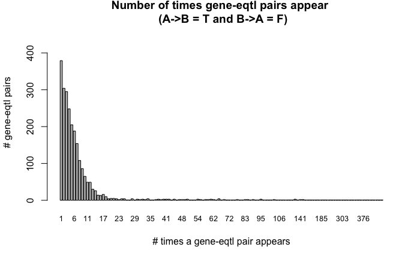

```r
# all values individually
bp2 <- barplot(numpairs.table2$numpairs, numpairs.table2$N, names.arg=unique(numpairs.table2$N),
               width = 0.5, space=0.2, legend.text = F, ylim = c(0,max(numpairs.table2$numpairs)+100),
               main = "Number of times gene-eqtl pairs appear \n (A->B = T and B->A = F)", xlab = "# times a gene-eqtl pair appears",
               ylab = "# gene-eqtl pairs", cex.names=0.8)
```

### Same, but grouping values

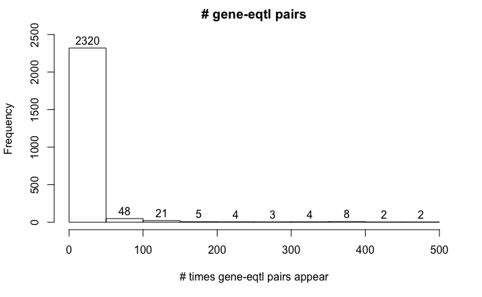

```r
hist(find.effects_TF.geneeqtl.A.plot$N, main = "# gene-eqtl pairs", xlab = "# times gene-eqtl pairs appear",labels = T, ylim = c(0,max(find.effects_TF.geneeqtl.A.plot$N)+2000))
```

the majority of gene-eqtl pairs appear between 0-50 times

### Plot network

```r
plot_TF <- graph_from_edgelist(as.matrix(find.effects_TF[,.(geneA, geneB)]),directed=TRUE)
```

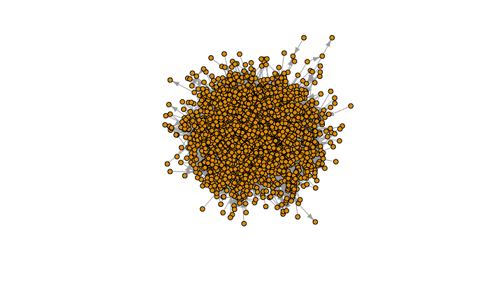

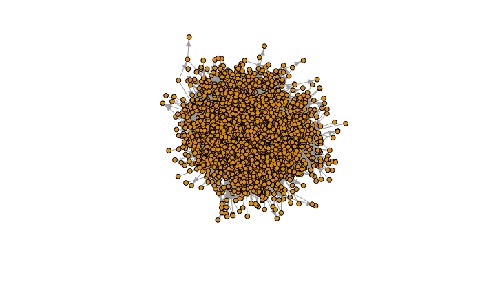

```r
V(plot_TF)$size <- 5
plot(plot_TF, layout=layout_with_fr,edge.arrow.size=.5, vertex.label=NA)
```

### Check how many groups of connected genes there are

```r
components(plot_TF)$no
```

```
[1] 1
```

if components(plot_TF)$no > 1, there are several groups and those groups are not connected to each other  
if components(plot_TF)$no == 1, all genes are connected

table where you have each gene and which group it belongs to  
- not interesting if there’s only one group

```r
memb <- components(plot_TF)$membership
nodes <- data.table(id = names(memb),
                    group_id = memb)
nodes <- nodes[order(nodes$id), ]
nodes
```

| id | group_id |
| --- | --- |
| YAL003W | 1 |
| YAL008W | 1 |
| YAL009W | 1 |
| YAL010C | 1 |
| YAL011W | 1 |
| YAL012W | 1 |
| YAL013W | 1 |
| YAL019W | 1 |
| YAL020C | 1 |
| YAL027W | 1 |

[output cut: 990 more lines]

# Testing with different parameters

```r
sign_p <- c(1e-17, 1e-16, 1e-15, 1e-14, 1e-13, 1e-12, 1e-11, 1e-10, 1e-9, 1e-8, 1e-7, 1e-6, 1e-5, 1e-4, 1e-3, 1e-2)
non_sign_p <- c(1e-7, 1e-6, 1e-5, 1e-4, 1e-3, 1e-2)
cor_p <- c(1e-9, 1e-8, 1e-7, 1e-6, 1e-5, 1e-4, 1e-3, 1e-2)
params0 <- data.table(expand.grid(sign_p=sign_p, non_sign_p=non_sign_p, cor_p=cor_p))
```

Ran on diprotodon

```r
# cl = makeCluster(detectCores()-2, type="FORK")
cl = makeCluster(4, type="FORK")
res <- parApply(cl=cl,params0,1, testparams, effects_table.cor)
stopCluster(cl)
```

the result is stored in res (list of tables)

```r
load(paste0(respath, "2020-01-20/20_01_2020_resparams.Rdata"))
```

## create summary table for number of unique gene pairs found and unique gene-eqtl pairs found (both for geneA (the one that has an effect) and for gene B)

one row per group of parameters

| geneA | geneB | eqtl.A | eqtl.B | unique.genepairs | unique.geneeqtlpairs.A | unique.geneeqtlpairs.B | sign.p | nonsign.p | cor.p |
| --- | --- | --- | --- | --- | --- | --- | --- | --- | --- |
| 1356 | 1268 | 1222 | 1187 | 8908 | 1407 | 1299 | 1e-17 | 1e-02 | 1e-09 |
| 1393 | 1274 | 1256 | 1193 | 9316 | 1446 | 1305 | 1e-17 | 1e-02 | 1e-08 |
| 1435 | 1292 | 1296 | 1208 | 9774 | 1491 | 1324 | 1e-17 | 1e-02 | 1e-07 |
| 1475 | 1305 | 1331 | 1219 | 10283 | 1533 | 1337 | 1e-17 | 1e-02 | 1e-06 |
| 1527 | 1325 | 1373 | 1237 | 10856 | 1585 | 1357 | 1e-17 | 1e-02 | 1e-05 |
| 1572 | 1334 | 1415 | 1243 | 11484 | 1634 | 1366 | 1e-17 | 1e-02 | 1e-04 |
| 1622 | 1350 | 1460 | 1256 | 12224 | 1686 | 1382 | 1e-17 | 1e-02 | 1e-03 |
| 1686 | 1366 | 1512 | 1269 | 13114 | 1751 | 1398 | 1e-17 | 1e-02 | 1e-02 |
| 1642 | 1317 | 1476 | 1230 | 10289 | 1701 | 1350 | 1e-17 | 1e-03 | 1e-09 |
| 1674 | 1323 | 1504 | 1235 | 10752 | 1734 | 1356 | 1e-17 | 1e-03 | 1e-08 |

[output cut: 758 more lines]

## plot number of unique gene pairs found when using different parameters combinations

one panel for each corr.pval  
The line colors represent different values for the non-significant pval threshold x-axis represents the significant p-val treshold

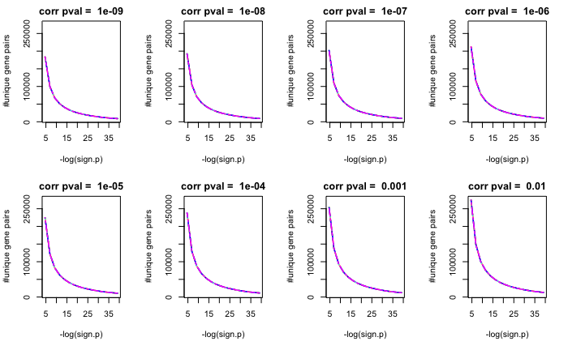

```r
par(mfrow=c(2,4))
cor.pvals <- unique(res_table$cor.p)
linetype <- c(1:length(unique(res_table$nonsign.p)))
for (p in cor.pvals){
  xrange <- range(-log(res_table$sign.p)) # set x-axis range
  yrange <- range(res_table$unique.genepairs) # set y-axis range
  plot(xrange, yrange, type = "n", main=paste("corr pval = ", p), xlab = "-log(sign.p)", ylab = " #unique gene pairs") # empty plot
  colors <- rainbow(length(unique(res_table$nonsign.p)))
  for (i in 1:length(unique(res_table$nonsign.p))){
    x <- -log(res_table[nonsign.p==nonsign.p[i] & cor.p==p]$sign.p)
    y <- res_table[nonsign.p==nonsign.p[i] & cor.p==p]$unique.genepairs
    lines(x,y,  type="l", lwd=1.5,lty=linetype[i], col=colors[i])
  }
  #legend(x=20, yrange[2], unique(res_table$nonsign.p), col=colors, lty=linetype, cex=0.8)
}
```

Plot without accounting for corr.pval  
different line colors represent different non-sign pval threshold  
x-axis represents the significant p-val treshold

```r
par(mfrow=c(1,1))
xrange <- range(-log(res_table$sign.p)) # set x-axis range
yrange <- range(res_table$unique.genepairs) # set y-axis range
plot(xrange, yrange, type = "n", xlab = "-log(p)", ylab = "#unique gene pairs",  main="#gene pairs where A->B") # empty plot
colors <- rainbow(length(unique(res_table$nonsign.p)))
linetype <- c(1:length(unique(res_table$nonsign.p)))
for (i in 1:length(unique(res_table$nonsign.p))){
  x <- -log(res_table$sign.p[res_table$nonsign.p==unique(res_table$nonsign.p)[i]])
  y <- res_table$unique.genepairs[res_table$nonsign.p==unique(res_table$nonsign.p)[i]]
  lines(x,y,  type="l", lwd=1.5,lty=linetype[i], col=colors[i])
}
```

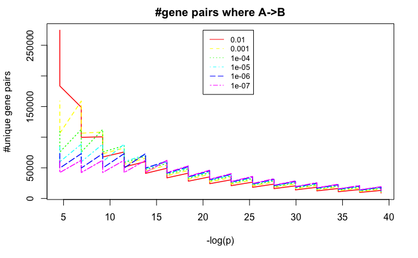

```r
legend(x=20, yrange[2], unique(res_table$nonsign.p), col=colors, lty=linetype, cex=0.8)
```